# Parte práctica: Detección de Anomalías

Ignacio Vellido Expósito

22/12/2020

# 1 Introducción

Vamos a usar el conjunto de datos `wine`, un dataset orientado a la clasificación multiclase de diferentes vinos en base a 13 atributos. Estos atributos miden las cantidades presentes de diferentes componentes químicos:

1. Alcohol
2. Malic acid
3. Ash
4. Alcalinity of ash
5. Magnesium
6. Total phenols
7. Flavanoids
8. Nonflavanoid phenols
9. Proanthocyanins
10. Color intensity
11. Hue
12. OD280/OD315 of diluted wines
13. Proline

Todos las variables son numéricas con valores reales. En nuestro caso ignoraremos la clase de prediccion y las etiquetas de valores anómalos proporcionadas en el dataset.

Referencias:

http://odds.cs.stonybrook.edu/wine-dataset/

https://archive.ics.uci.edu/ml/datasets/Wine

**NOTA**: Es necesario mencionar que cada vino distinto (cada instancia) únicamente viene identificada por su posición en la tabla. Es decir, no tenemos un nombre o algún identificador para referenciarla. Por tanto, cuando hablemos de instancias concretas durante la práctica se mencionará únicamente la “clave” del vino en cuestión y no su nombre. Esto implica que en los apartados que tenían la etiqueta `# COMPLETAR` se incluirá el cálculo de los nombres pero aparecerá su salida comentada.

# 2 Selección de Variables

El conjunto de datos inicial tiene la siguiente forma:

|  | Alcohol | Malic | Ash | Alcalinity | Mag | Phenols | Flavanoids | Non-flava | Proantho | Color | Hue | OD280 | Proline | Anomaly |
| --- | --- | --- | --- | --- | --- | --- | --- | --- | --- | --- | --- | --- | --- | --- |
| 1 | 13.29 | 1.97 | 2.68 | 16.8 | 102 | 3.00 | 3.23 | 0.31 | 1.66 | 6.00 | 1.07 | 2.84 | 1270 | 1 |
| 2 | 14.30 | 1.92 | 2.72 | 20.0 | 120 | 2.80 | 3.14 | 0.33 | 1.97 | 6.20 | 1.07 | 2.65 | 1280 | 1 |
| 3 | 13.68 | 1.83 | 2.36 | 17.2 | 104 | 2.42 | 2.69 | 0.42 | 1.97 | 3.84 | 1.23 | 2.87 | 990 | 1 |
| 4 | 14.06 | 2.15 | 2.61 | 17.6 | 121 | 2.60 | 2.51 | 0.31 | 1.25 | 5.05 | 1.06 | 3.58 | 1295 | 1 |
| 5 | 14.22 | 1.70 | 2.30 | 16.3 | 118 | 3.20 | 3.00 | 0.26 | 2.03 | 6.38 | 0.94 | 3.31 | 970 | 1 |
| 6 | 14.10 | 2.02 | 2.40 | 18.8 | 103 | 2.75 | 2.92 | 0.32 | 2.38 | 6.20 | 1.07 | 2.75 | 1060 | 1 |

Y las medidas estadísticas:

```
    Alcohol          Malic            Ash          Alcalinity         Mag
 Min.   :11.03   Min.   :0.740   Min.   :1.360   Min.   :10.60   Min.   : 70.00
 1st Qu.:12.21   1st Qu.:1.510   1st Qu.:2.200   1st Qu.:18.50   1st Qu.: 87.00
 Median :12.64   Median :2.060   Median :2.320   Median :20.00   Median : 95.00
 Mean   :12.73   Mean   :2.446   Mean   :2.336   Mean   :20.45   Mean   : 97.45
 3rd Qu.:13.29   3rd Qu.:3.270   3rd Qu.:2.530   3rd Qu.:22.00   3rd Qu.:104.00
 Max.   :14.34   Max.   :5.800   Max.   :3.230   Max.   :30.00   Max.   :162.00
    Phenols        Flavanoids      Non-flava         Proantho         Color
 Min.   :0.980   Min.   :0.340   Min.   :0.1300   Min.   :0.410   Min.   : 1.280
 1st Qu.:1.630   1st Qu.:0.800   1st Qu.:0.2900   1st Qu.:1.040   1st Qu.: 2.850
 Median :2.000   Median :1.590   Median :0.4000   Median :1.420   Median : 4.000
 Mean   :2.089   Mean   :1.663   Mean   :0.3914   Mean   :1.468   Mean   : 4.902
 3rd Qu.:2.500   3rd Qu.:2.260   3rd Qu.:0.4800   3rd Qu.:1.770   3rd Qu.: 6.300
 Max.   :3.520   Max.   :5.080   Max.   :0.6600   Max.   :3.580   Max.   :13.000
      Hue             OD280          Proline
 Min.   :0.4800   Min.   :1.270   Min.   : 278.0
 1st Qu.:0.7200   1st Qu.:1.750   1st Qu.: 465.0
 Median :0.9200   Median :2.440   Median : 564.0
 Mean   :0.9187   Mean   :2.391   Mean   : 612.1
 3rd Qu.:1.0700   3rd Qu.:2.960   3rd Qu.: 685.0
 Max.   :1.7100   Max.   :3.690   Max.   :1450.0
```

Aunque contamos con reales, mostramos también la ocurrencia de cada valor:

```
$Alcohol

11.03 11.41 11.45 11.46 11.56 11.61 11.62 11.64 11.65 11.66 11.76 11.79 11.81 11.82 11.84
    1     1     1     1     1     1     1     1     1     1     1     1     1     2     2
11.87 11.96    12 12.04 12.07 12.08 12.16 12.17  12.2 12.21 12.22 12.25 12.29 12.33 12.34
    1     1     3     1     1     5     1     1     1     1     1     3     4     2     1
12.36 12.37 12.42 12.43 12.45 12.47 12.51 12.52 12.53 12.58  12.6 12.64 12.67 12.69  12.7
    1     6     3     1     1     1     2     1     1     1     2     1     1     1     2
12.72 12.77 12.79 12.81 12.82 12.84 12.85 12.86 12.87 12.88 12.93 12.96 12.99 13.03 13.05
    2     2     1     1     1     1     1     1     1     1     1     1     1     1     3
13.08 13.11 13.16 13.17 13.23 13.27 13.29 13.32 13.34 13.36  13.4 13.45 13.48 13.49  13.5
    1     2     1     2     1     1     1     1     1     1     2     1     1     2     1
13.52 13.58 13.62 13.67 13.68 13.69 13.71 13.73 13.77 13.78 13.84 13.86 13.88 14.06  14.1
    1     1     1     1     1     1     1     1     1     1     1     2     1     1     1
14.13 14.16  14.2 14.22  14.3 14.34
    1     1     1     1     1     1

$Malic

0.74 0.89  0.9 0.92 0.94 0.98 0.99 1.01 1.07 1.09  1.1 1.13 1.17 1.19 1.21 1.24 1.25 1.29
   1    1    1    1    2    1    1    1    1    1    1    2    1    1    1    1    1    2
1.33 1.34 1.35 1.36 1.39 1.41 1.45 1.47 1.51 1.52 1.53 1.61 1.63 1.65 1.66 1.67 1.68  1.7
   1    1    3    1    1    1    1    1    3    1    2    3    1    1    1    3    1    1
1.72 1.73 1.75 1.76 1.81 1.83 1.88  1.9 1.92 1.97 1.99 2.02 2.05 2.06 2.08 2.12 2.13 2.15
   1    2    1    1    1    2    1    2    1    1    1    1    1    1    1    1    1    1
2.16 2.31 2.39  2.4 2.43 2.45 2.46 2.51 2.55 2.56 2.58 2.59 2.67 2.68 2.76 2.81 2.83 2.89
   1    1    1    1    1    1    1    1    1    1    1    1    1    1    1    1    1    1
2.96 2.99 3.03 3.12 3.17 3.24 3.26 3.27  3.3 3.37 3.43 3.45 3.55 3.57 3.59  3.7 3.74 3.83
   1    1    2    1    2    1    1    1    1    1    2    1    1    1    1    1    1    1
3.86 3.87 3.88  3.9 3.91  4.1 4.12 4.28  4.3 4.31 4.36 4.43  4.6 4.61 4.72 4.95 5.04 5.19
   1    1    1    1    1    1    1    1    1    1    1    1    1    1    1    1    1    1
5.51 5.65  5.8
   1    1    1

$Ash

1.36  1.7 1.71 1.75 1.82 1.88  1.9 1.92 1.94 1.95 1.98 1.99    2 2.02  2.1 2.12 2.13 2.15
   1    2    1    1    1    1    1    3    1    1    3    1    2    1    2    1    1    1
2.16 2.17 2.19  2.2 2.21 2.22 2.23 2.24 2.25 2.26 2.27 2.28 2.29  2.3 2.31 2.32 2.35 2.36
   1    2    2    5    2    1    2    2    1    3    2    5    1    6    1    5    3    4
```

[output cut: 121 more lines]

```
3.55 3.57 3.58 3.64 3.69
   1    1    1    1    1

$Proline

 278  290  312  315  325  342  345  352  355  365  372  378  380  385  392  406  407  410
   1    1    1    1    1    1    2    1    1    1    1    1    2    1    1    1    1    1
 415  420  425  428  434  438  450  463  465  466  470  472  480  488  495  500  502  510
   2    1    1    2    1    1    3    1    1    1    1    1    3    1    3    2    1    3
 515  520  530  550  560  562  564  570  580  590  600  607  615  620  625  630  640  650
   2    5    1    2    2    3    1    1    2    1    2    1    1    1    4    4    1    2
 660  672  675  678  680  685  695  710  714  718  720  725  740  750  780  830  835  840
   3    1    2    1    4    1    2    1    1    1    1    1    1    4    1    1    1    1
 855  870  880  886  937  970  985  990 1045 1060 1105 1270 1280 1295 1375 1450
   1    1    1    1    1    1    1    1    1    1    1    1    1    1    1    1
```

Vemos que cada columna contiene variedad suficiente y sin valores nulos, por lo que no eliminamos ninguna.

# 3 Detección de outliers en una dimensión

## 3.1 Outliers IQR

Los métodos IQR teóricamente solo se deben aplicar a distribuciones normales, pero también pueden funcionar si la forma de la distribución no es rara (multimodal, uniforme…).

De cara a elegir aquellas variables, mostramos un histograma de cada una:

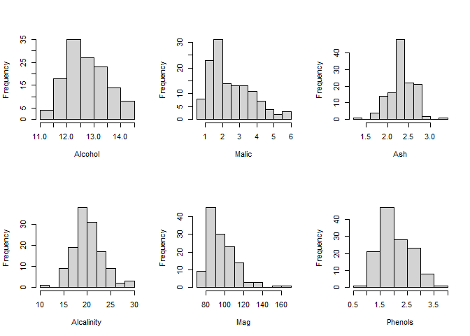

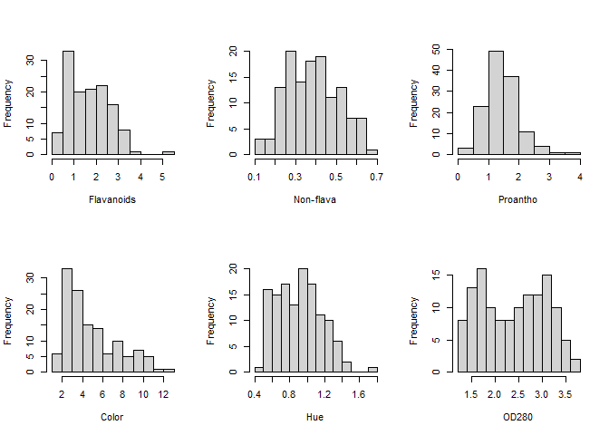

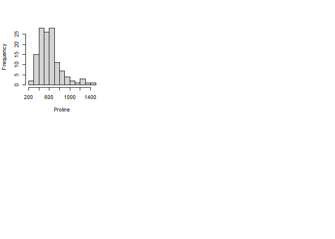

```r
par(mfrow = c(2,3))
c(1:ncol(datos.num)) %>% sapply(function(x) hist(datos.num[,x],
                                                 main="",
                                                 xlab=names(datos.num)[x])) -> c
```

En general la mayoría de variables parecen seguir distribuciones no muy raras, excepto `OD280` que parece ser bimodal.

De cara a elegir una de estas variables, y únicamente por tener un criterio más de desempate, aplicamos un test de normalidad a cada una.

```r
print("Shapiro test, p-values:")
sapply(datos.num, function(x) {
  shapiro.test(x)$p.value}
)
```

```
[1] "Shapiro test, p-values:"
     Alcohol        Malic          Ash   Alcalinity          Mag      Phenols
4.218621e-02 1.755726e-06 7.977658e-02 1.007916e-01 3.371724e-08 1.355065e-03
  Flavanoids    Non-flava     Proantho        Color          Hue        OD280
3.600137e-05 4.197448e-02 6.182303e-04 8.354265e-08 8.469191e-03 4.798788e-05
     Proline
2.482259e-08
```

Vemos que existen varias a las que el test no rechaza. De aquellas, elegimos la que obtiene mayor p-value (`Alcalinity`), que vimos en el histograma que se asemeja bastante a una normal.

### 3.1.1 Obtención de los outliers IQR

Calculamos los cuartiles:

```r
cuartil.primero <- quantile(columna, .25, names = F)
cuartil.tercero <- quantile(columna, .75, names = F)
iqr <- IQR(columna)
```

```
Q1: [1] 18.5

Q3: [1] 22

IQR: [1] 3.5
```

Y calculamos los extremos:

```r
extremo.superior.outlier.IQR <- cuartil.tercero + 1.5 * iqr
extremo.inferior.outlier.IQR <- cuartil.primero - 1.5 * iqr
extremo.superior.outlier.IQR.extremo <- cuartil.tercero + 3 * iqr
extremo.inferior.outlier.IQR.extremo <- cuartil.primero - 3 * iqr
```

```
Extremo superior: [1] 27.25
Extremo inferior: [1] 13.25
Extremo superior extremo: [1] 32.5
Extremo inferior extremo: [1] 8
```

Construimos vectores lógicos indicando si cada instancia es o no un outlier (normal o extremo):

```r
son.outliers.IQR <- columna < extremo.inferior.outlier.IQR | columna > extremo.superior.outlier.IQR
son.outliers.IQR.extremos <- columna < extremo.inferior.outlier.IQR.extremo | columna > extremo.superior.outlier.IQR.extremo
```

```r
head(son.outliers.IQR)
head(son.outliers.IQR.extremos)
sum(son.outliers.IQR)
sum(son.outliers.IQR.extremos)
```

```
[1] FALSE FALSE FALSE FALSE FALSE FALSE
[1] FALSE FALSE FALSE FALSE FALSE FALSE
[1] 4
[1] 0
```

### 3.1.2 Índices y valores de los outliers IQR

Obtenemos ahora los índices de las instancias que se detectan como outliers con el método IQR

```r
claves.outliers.IQR <- which(son.outliers.IQR)
df.outliers.IQR <- datos.num[claves.outliers.IQR,]
nombres.outliers.IQR <- row.names(df.outliers.IQR)
valores.outliers.IQR <- columna[claves.outliers.IQR]

claves.outliers.IQR.extremos <- which(son.outliers.IQR.extremos)
df.outliers.IQR.extremos <- datos.num[claves.outliers.IQR.extremos,]
nombres.outliers.IQR.extremos <- row.names(df.outliers.IQR.extremos)
valores.outliers.IQR.extremos <- columna[claves.outliers.IQR.extremos]
```

```r
claves.outliers.IQR
```

```
[1] 11 25 73 79
```

```r
df.outliers.IQR
```

|  | Alcohol | Malic | Ash | Alcalinity | Mag | Phenols | Flavanoids | Non-flava | Proantho | Color | Hue | OD280 | Proline |
| --- | --- | --- | --- | --- | --- | --- | --- | --- | --- | --- | --- | --- | --- |
| 11 | 12.37 | 0.94 | 1.36 | 10.6 | 88 | 1.98 | 0.57 | 0.28 | 0.42 | 1.95 | 1.05 | 1.82 | 520 |
| 25 | 12.99 | 1.67 | 2.60 | 30.0 | 139 | 3.30 | 2.89 | 0.21 | 1.96 | 3.35 | 1.31 | 3.50 | 985 |
| 73 | 11.56 | 2.05 | 3.23 | 28.5 | 119 | 3.18 | 5.08 | 0.47 | 1.87 | 6.00 | 0.93 | 3.69 | 465 |
| 79 | 11.79 | 2.13 | 2.78 | 28.5 | 92 | 2.13 | 2.24 | 0.58 | 1.76 | 3.00 | 0.97 | 2.44 | 466 |

```r
# nombres.outliers.IQR
valores.outliers.IQR
```

```
[1] 10.6 30.0 28.5 28.5
```

```r
claves.outliers.IQR.extremos
```

```
integer(0)
```

```r
df.outliers.IQR.extremos
```

| Alcohol | Malic | Ash | Alcalinity | Mag | Phenols | Flavanoids | Non-flava | Proantho | Color | Hue | OD280 | Proline |
| --- | --- | --- | --- | --- | --- | --- | --- | --- | --- | --- | --- | --- |

```r
# nombres.outliers.IQR.extremos
valores.outliers.IQR.extremos
```

```
numeric(0)
```

### 3.1.3 Cómputo de los outliers IQR con funciones

La misma información anterior podemos calcularlas con las funciones proporcionadas:

```
[1] 11 25 73 79
```

|  | Alcohol | Malic | Ash | Alcalinity | Mag | Phenols | Flavanoids | Non-flava | Proantho | Color | Hue | OD280 | Proline |
| --- | --- | --- | --- | --- | --- | --- | --- | --- | --- | --- | --- | --- | --- |
| 11 | 12.37 | 0.94 | 1.36 | 10.6 | 88 | 1.98 | 0.57 | 0.28 | 0.42 | 1.95 | 1.05 | 1.82 | 520 |
| 25 | 12.99 | 1.67 | 2.60 | 30.0 | 139 | 3.30 | 2.89 | 0.21 | 1.96 | 3.35 | 1.31 | 3.50 | 985 |
| 73 | 11.56 | 2.05 | 3.23 | 28.5 | 119 | 3.18 | 5.08 | 0.47 | 1.87 | 6.00 | 0.93 | 3.69 | 465 |
| 79 | 11.79 | 2.13 | 2.78 | 28.5 | 92 | 2.13 | 2.24 | 0.58 | 1.76 | 3.00 | 0.97 | 2.44 | 466 |

```
integer(0)
```

### 3.1.4 Desviación de los outliers con respecto a la media de la columna

Calcularemos ahora la desviación de cada outlier respecto a la media de su columna.

Para ello, aplicaremos el método z-score para aproximar la distribución a una N(0,1) y observaremos los valores de cada outlier en la variable seleccionada (`Alcalinity`). Dataset normalizado:

```
    Alcohol      Malic         Ash Alcalinity       Mag   Phenols Flavanoids  Non-flava
1 0.7583092 -0.3917840  1.21887202 -1.1967410 0.3071914 1.5640700  1.7267788 -0.6372705
2 2.1171333 -0.4329673  1.36071640 -0.1472091 1.5223505 1.2208447  1.6276152 -0.4806841
3 1.2830037 -0.5070972  0.08411701 -1.0655495 0.4422091 0.5687165  1.1317973  0.2239551
4 1.7942444 -0.2435242  0.97064436 -0.9343580 1.5898593 0.8776193  0.9334701 -0.6372705
5 2.0095037 -0.6141738 -0.12864955 -1.3607304 1.3873328 1.9072954  1.4733608 -1.0287367
6 1.8480592 -0.3506007  0.22596139 -0.5407835 0.3747002 1.1350383  1.3852154 -0.5589773
    Proantho       Color        Hue     OD280  Proline
1  0.3357835  0.42296395 0.61231157 0.6531463 2.917767
2  0.8767980  0.50000765 0.61231157 0.3768975 2.962116
3  0.8767980 -0.40910802 1.25995484 0.6967645 1.675988
4 -0.3797519  0.05700637 0.57183387 1.7290626 3.028640
5  0.9815105  0.56934698 0.08610141 1.3364985 1.587290
6  1.5923333  0.50000765 0.61231157 0.5222916 1.986433
```

Mostramos primeramente un gráfico de la variable:

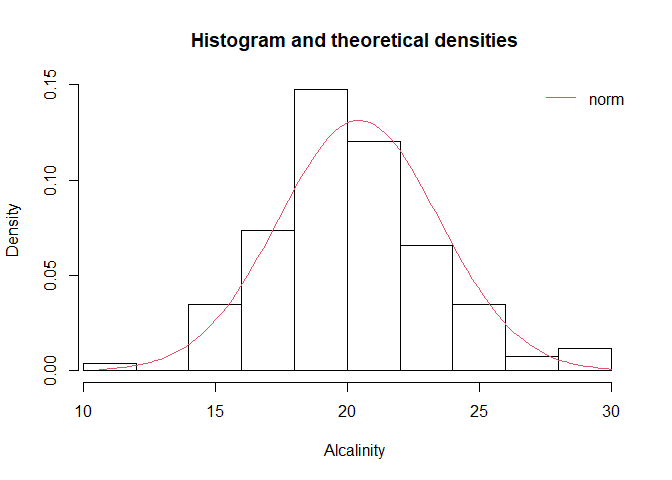

Obtenemos los valores normalizados de los outliers:

```r
valores.outliers.IQR.norm <- columna.norm[claves.outliers.IQR]
names(valores.outliers.IQR.norm) <- claves.outliers.IQR

valores.outliers.IQR.norm
```

```
       11        25        73        79
-3.230209  3.132578  2.640610  2.640610
```

Apreciamos que las instancias 11 y 25 toman valores mucho más alejados que 73 y 79. Aún así, ninguno llega a considerarse extremo en una N(0,1) puesto que no son más grandes que ±4.69. Hacemos notar también que si la variable Alcalinity se aproximara perfectamente a una N(0,1) las instancias 73 y 79 no se considerarían outliers, por estar por debajo del umbral ±2.68.

Mostramos ahora el comportamiento de estos outliers con el resto de columnas (normalizadas):

```r
datos.num.norm.outliers.IQR <- datos.num.norm[claves.outliers.IQR,]
rownames(datos.num.norm.outliers.IQR) <- claves.outliers.IQR

datos.num.norm.outliers.IQR %>% as.data.frame()
```

|  | Alcohol | Malic | Ash | Alcalinity | Mag | Phenols | Flavanoids | Non-flava | Proantho | Color | Hue | OD280 | Proline |
| --- | --- | --- | --- | --- | --- | --- | --- | --- | --- | --- | --- | --- | --- |
| 11 | -0.4794316 | -1.2401598 | -3.4619924 | -3.230209 | -0.6379324 | -0.18637936 | -1.2040560 | -0.8721503 | -1.8282746 | -1.1371710 | 0.53135616 | -0.82987340 | -0.4084255 |
| 25 | 0.3546981 | -0.6388838 | 0.9351833 | 3.132578 | 2.8050184 | 2.07890809 | 1.3521608 | -1.4202029 | 0.8593459 | -0.5978651 | 1.58377648 | 1.61274732 | 1.6538139 |
| 73 | -1.5691817 | -0.3258907 | 3.1692322 | 2.640610 | 1.4548416 | 1.87297287 | 3.7651414 | 0.6154213 | 0.7022772 | 0.4229639 | 0.04562371 | 1.88899609 | -0.6523463 |
| 79 | -1.2597465 | -0.2599975 | 1.5734830 | 2.640610 | -0.3678970 | 0.07103967 | 0.6359794 | 1.4766469 | 0.5103043 | -0.7326916 | 0.20753453 | 0.07156996 | -0.6479114 |

Vemos que las instancias 11 y 73 tienen adicionalmente un valor extremo en la columnas `Ash`, la 25 obtiene otro en `Mag` y la 79 es la única que parece tener un valor excesivamente grande en una sola columna (no lo podemos afirmar de forma estadística puesto que no sabemos si el resto de variables provienen de una normal).

### 3.1.5 Gráficos

Mostramos en un gráfico los valores de los registros respecto a diferentes variables, concretamente Alcalinity-Alcohol, Alcalinity-Ash y Alcalinity-Mag.

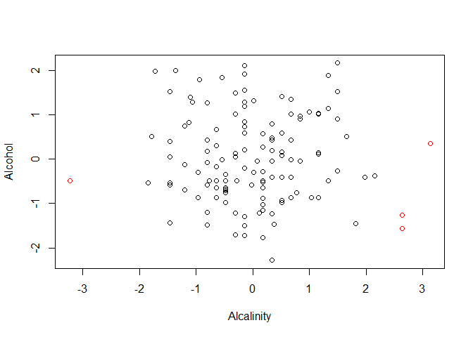

```r
plot_2_colores(datos.num.norm[,c(4,1)], claves.outliers.IQR)
```

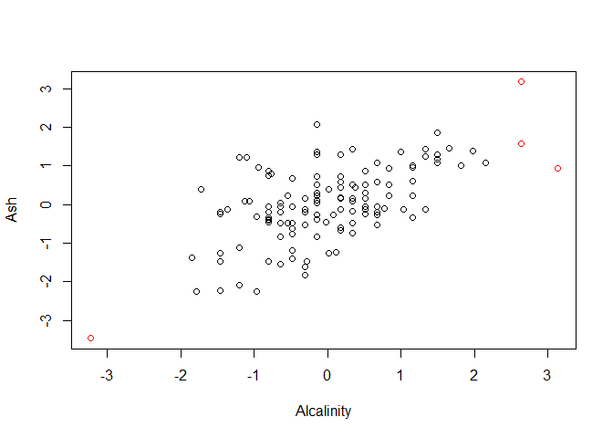

```r
plot_2_colores(datos.num.norm[,c(4,3)], claves.outliers.IQR)
```

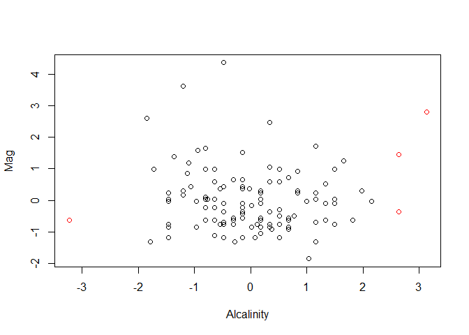

```r
plot_2_colores(datos.num.norm[,c(4,5)], claves.outliers.IQR)
```

Tal y como habíamos visto, en las tres gráficas los outliers se ubican alejados de la nube de puntos, 3 de ellos por arriba en el Alcalinity y 1 por debajo.

No tenemos valores extremos, pero si los tuviéramos los mostraríamos con la sentencia:

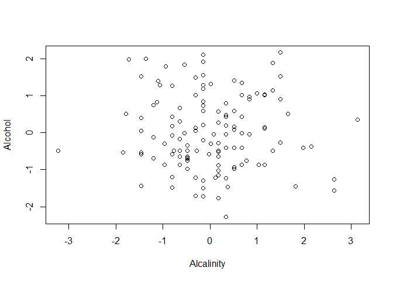

```r
plot_2_colores(datos.num.norm[,c(4,1)], claves.outliers.IQR.extremos)
```

### 3.1.6 Diagrama de cajas

Mostramos diagramas de cajas con los outliers destacados:

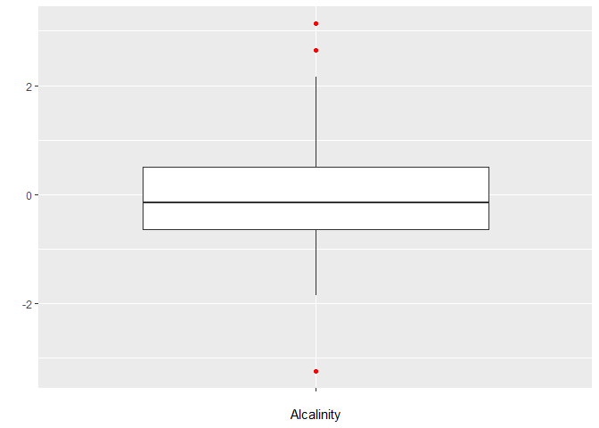

```r
diag_caja_outliers_IQR(datos.num.norm, 4)
```

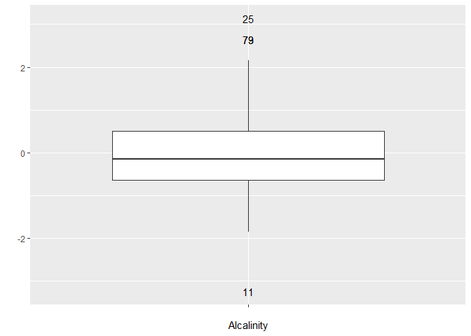

```r
# La función original tiene un fallo, solo muestra la última clave.
# Para corregirlo, se debe cambiar la línea:
# for (i in num.claves)
# Por:
# for (i in 1:num.claves)
diag_caja(datos.num.norm, 4, claves.outliers.IQR)
```

No se muestran los extremos por no tener ninguno.

Mostramos ahora los outlilers en todas las variables:

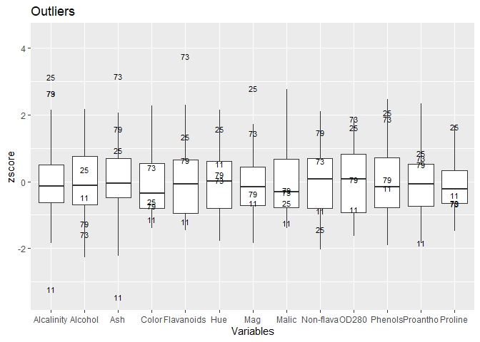

Como habíamos analizado antes, solo la instancia 79 parece ser un outliers en una sola columna. Para el resto, vemos que más o menos habíamos acertado, solo la 11 parece también estar un tanto alejada de su media en la columna `Proantho`.

## 3.2 Test de hipótesis

Haciendo uso de un test de hipótesis determinaremos si el valor más alejado de la media se puede considerar un outlier.

### 3.2.1 Comprobación de la hipótesis de Normalidad

Puesto que vamos a aplicar el test de Grubs, tenemos que comprobar previamente que la distribución que sigue la variable **sin el outlier** sigue una distribución normal (por tanto, el test de Shapiro que aplicamos anteriormente no nos vale).

Primeramente, podemos ver de forma gráfica la distribución de la variable elegida:

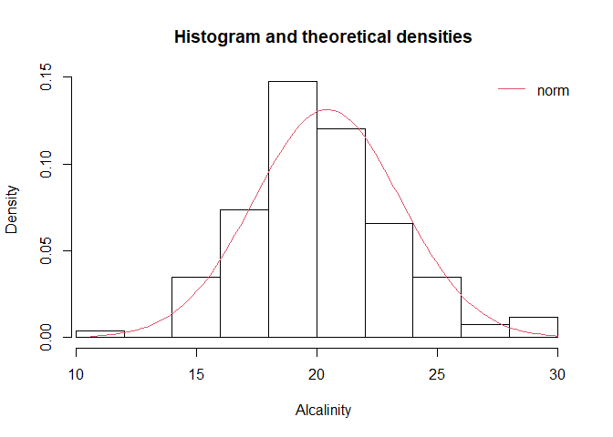

Los valores extremos pueden ser problemáticos para que la distribución sea normal, pero visualmente apreciamos un buen ajuste con la curva.

### 3.2.2 Test de Grubs

Más adelante se aplicará el test de normalidad sobre la variable sin el outlier. Antes, basándonos en el gráfico anterior y suponiendo que la distribución es normal, podemos hacer el test de Grubs sobre el valor más alejado de la media, obteniendo un p-value de:

```r
test.de.Grubbs = grubbs.test(columna, two.sided = TRUE)
test.de.Grubbs$p.value
```

```
[1] 0.1278085
```

Mostramos adicionalmente el valor de la instancia:

```r
valor.posible.outlier = outlier(columna)
valor.posible.outlier
```

```
[1] 10.6
```

Y su clave:

```r
es.posible.outlier = outlier(columna, logical = TRUE)
clave.posible.outlier = which( es.posible.outlier == TRUE)
clave.posible.outlier
```

```
[1] 11
```

Tenemos un p-value > 0.05, por lo que el test no rechaza la hipótesis de que el valor más alejado de la media (en este caso la instancia 11) no es un outlier. Aunque tenga un valor bajo para la variable Alcalinity no podemos concluir con garantía estadística que es una anomalía.

### 3.2.3 Test de Normalidad

Pasamos los tests de Normalidad al conjunto de datos eliminando previamente el outlier (instancia 11):

```r
datos.sin.outlier = columna[-clave.posible.outlier]
cat("Datos sin outlier:\n")
datos.sin.outlier

shapiro.test(datos.sin.outlier)

goodness_fit = gofstat(ajusteNormal)
goodness_fit$adtest
```

```
Datos sin outlier:
  [1] 16.8 20.0 17.2 17.6 16.3 18.8 16.0 18.0 15.2 17.1 16.0 16.8 18.0 19.0 19.0 18.1 15.0
 [18] 19.6 17.0 16.8 20.4 25.0 24.0 30.0 21.0 16.0 16.0 18.0 14.8 23.0 19.0 18.8 24.0 22.5
 [35] 18.0 18.0 22.8 26.0 21.6 23.6 18.5 22.0 20.7 18.0 18.0 19.0 21.5 16.0 18.5 18.0 17.5
 [52] 18.5 21.0 19.5 20.5 22.0 19.0 22.5 19.0 20.0 19.5 21.0 20.0 21.0 22.5 21.5 20.8 22.5
 [69] 16.0 19.0 20.0 28.5 26.5 21.5 21.0 21.0 21.5 28.5 24.5 22.0 18.0 20.0 24.0 21.5 17.5
 [86] 18.5 21.0 25.0 19.5 24.0 21.0 20.0 23.5 20.0 18.5 21.0 20.0 21.5 21.5 21.5 24.0 22.0
[103] 25.5 18.5 20.0 22.0 19.5 27.0 25.0 22.5 21.0 20.0 22.0 18.5 22.0 22.5 23.0 19.5 24.5
[120] 25.0 19.0 19.5 20.0 20.5 23.0 20.0 20.0 24.5

    Shapiro-Wilk normality test

data:  datos.sin.outlier
W = 0.97578, p-value = 0.02141

    1-mle-norm
"not computed"
```

El test de Anderson-Darling no se aplica por tener pocos datos. Para el test de Shapiro, esta vez sin el outlier, vemos que ahora se rechaza (p-value < 0.05) por lo que afirma con significación que la columna no sigue una distribución normal. Tal y como habíamos visto anteriormente, el test con el outlier no rechazaba, por lo que este modificaba la media lo suficiente para hacer creer al estadístico que la distribución era normal. No deberíamos por tanto aplicar el test de Grubs sobre la columna Alcalinity, pues esta normalidad es una condición necesaria.

Pese a ello, proseguimos con el apartado.

Construímos una función que nos calcula toda la información necesaria para aplicar un test de Grubs sobre una columna.

```r
#######################################################################
# Aplica el test de Grubbs sobre la columna ind.col de datos y devuelve una lista con:

# nombre.columna: Nombre de la columna datos[, ind.col]
# clave.mas.alejado.media: Clave del valor O que está más alejado de la media
# valor.mas.alejado.media: Valor de O en datos[, ind.col]
# nombre.mas.alejado.media: Nombre de O en datos
# es.outlier: TRUE/FALSE dependiendo del resultado del test de Grubbs sobre O
# p.value:  p-value calculado por el test de Grubbs
# es.distrib.norm: Resultado de aplicar el test de Normalidad
#    de Shapiro-Wilks sobre datos[, ind.col]
#    El test de normalidad se aplica sin tener en cuenta el
#    valor más alejado de la media (el posible outlier O)
#    TRUE si el test no ha podido rechazar
#       -> Sólo podemos concluir que los datos no contradicen una Normal
#    FALSE si el test rechaza
#       -> Los datos no siguen una Normal

# Requiere el paquete outliers

test_Grubbs = function(datos, ind.col, alpha = 0.05) {
  columna <- datos[,ind.col]
  res <- list()

  # Nombre columna
  res$nombre.columna <- colnames(datos)[ind.col]

  # Búsqueda del outlier
  es.posible.outlier <- outlier(columna, logical = TRUE)

  res$clave.mas.alejado.media <- which(es.posible.outlier == TRUE)
  res$valor.mas.alejado.media <- outlier(columna)
  res$nombre.mas.alejado.media <- rownames(datos)[res$clave.mas.alejado.media]

  # Test de Grubbs
  test.de.Grubbs = grubbs.test(columna, two.sided = TRUE)

  res$es.outlier <- ifelse(test.de.Grubbs$p.value <= alpha, TRUE, FALSE)
  res$p.value <- test.de.Grubbs$p.value

  # Test de normalidad
  test.Normalidad <- shapiro.test(columna[-res$clave.mas.alejado.media])
  res$es.distrib.norm <- ifelse(test.Normalidad$p.value > alpha, TRUE, FALSE)

  res
}
```

Aplicamos la función a nuestro dataset, obteniendo:

```
$nombre.columna
[1] "Alcalinity"

$clave.mas.alejado.media
[1] 11

$valor.mas.alejado.media
[1] 10.6

$nombre.mas.alejado.media
[1] "11"

$es.outlier
[1] FALSE

$p.value
[1] 0.1278085

$es.distrib.norm
[1] FALSE
```

## 3.3 Trabajando con varias columnas

Aplicamos los métodos anteriores simultáneamente sobre varias columnas.

### 3.3.1 Outliers IQR

Calculamos los outliers IQR

```
[1] "Claves outliers IQR en mas de una columna:"
[1] 11 73 25 47
[1] "Claves outliers IQR en alguna columna:"
 [1]  11  18  52  73  25  79  21  30  47  48  62  76 110 111  67   1   2   4   6   7   8
[22]   9  10
```

Los valores normalizados de algunos de estos outliers son:

```r
datos.num.norm[claves.outliers.IQR.en.alguna.columna,] %>% head() %>% as.data.frame()
```

|  | Alcohol | Malic | Ash | Alcalinity | Mag | Phenols | Flavanoids | Non-flava | Proantho | Color | Hue | OD280 | Proline |
| --- | --- | --- | --- | --- | --- | --- | --- | --- | --- | --- | --- | --- | --- |
| 11 | -0.4794316 | -1.2401598 | -3.4619924 | -3.2302091 | -0.63793236 | -0.18637936 | -1.2040560 | -0.8721503 | -1.8282746 | -1.1371710 | 0.53135616 | -0.82987340 | -0.4084255 |
| 18 | 0.5161425 | -1.1825032 | -2.2563152 | -1.7871027 | -1.31302075 | 1.52974750 | 1.6716879 | -1.0287367 | 1.4178125 | 0.1533110 | 0.81470009 | 1.14748623 | -0.4882541 |
| 52 | -0.8695890 | -0.3011808 | -2.2563152 | -0.9671559 | -0.03035281 | 0.24265236 | 0.5588521 | -1.0287367 | -0.1179707 | -0.6171260 | 1.42186566 | 0.82761923 | 0.4342099 |
| 73 | -1.5691817 | -0.3258907 | 3.1692322 | 2.6406101 | 1.45484164 | 1.87297287 | 3.7651414 | 0.6154213 | 0.7022772 | 0.4229639 | 0.04562371 | 1.88899609 | -0.6523463 |
| 25 | 0.3546981 | -0.6388838 | 0.9351833 | 3.1325782 | 2.80501842 | 2.07890809 | 1.3521608 | -1.4202029 | 0.8593459 | -0.5978651 | 1.58377648 | 1.61274732 | 1.6538139 |
| 79 | -1.2597465 | -0.2599975 | 1.5734830 | 2.6406101 | -0.36789701 | 0.07103967 | 0.6359794 | 1.4766469 | 0.5103043 | -0.7326916 | 0.20753453 | 0.07156996 | -0.6479114 |

De forma gráfica (puesto que hay una gran cantidad de puntos los separamos en dos gráficos):

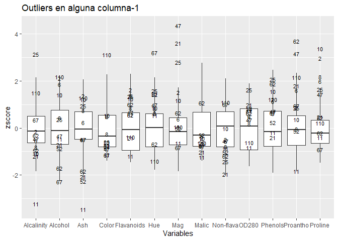

```r
diag_caja_juntos(datos.num.norm, "Outliers en alguna columna-1", claves.outliers.IQR.en.alguna.columna[c(T,F)])
```

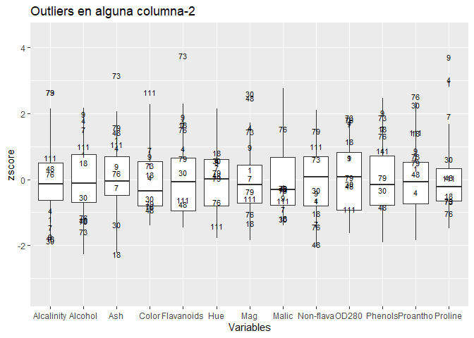

```r
diag_caja_juntos(datos.num.norm, "Outliers en alguna columna-2", claves.outliers.IQR.en.alguna.columna[c(F,T)])
```

Notamos valores extremadamente altos en Mag y Proline, y solo unas pocas variables sin outliers. También vemos que muchos outliers lo son en más de una columna, pero ninguno parece que en más de tres.

Además, apreciamos en Mag (cantidad de Magnesio) valores extremádamente altos, sobre todo en la instancia 47. Una búsqueda rápida por internet nos dice que la cantidad magnesio en los vinos es baja, cosa que hace aún más llamativa esta instancia.

|  | Alcohol | Malic | Ash | Alcalinity | Mag | Phenols | Flavanoids | Non-flava | Proantho | Color | Hue | OD280 | Proline |
| --- | --- | --- | --- | --- | --- | --- | --- | --- | --- | --- | --- | --- | --- |
| 47 | 12.47 | 1.52 | 2.2 | 19 | 162 | 2.5 | 2.27 | 0.32 | 3.28 | 2.6 | 1.16 | 2.63 | 937 |

```
   Min. 1st Qu.  Median    Mean 3rd Qu.    Max.
  70.00   87.00   95.00   97.45  104.00  162.00
```

De los valores altos en Proline (2,4,9,10) vemos que todos tienen valores similares en el resto de variables. La Proline es el aminoácido más abundante en los vinos y parece variar en base al tipo de fermentación que ha sufrido el vino.

|  | Alcohol | Malic | Ash | Alcalinity | Mag | Phenols | Flavanoids | Non-flava | Proantho | Color | Hue | OD280 | Proline |
| --- | --- | --- | --- | --- | --- | --- | --- | --- | --- | --- | --- | --- | --- |
| 2 | 14.30 | 1.92 | 2.72 | 20.0 | 120 | 2.80 | 3.14 | 0.33 | 1.97 | 6.20 | 1.07 | 2.65 | 1280 |
| 4 | 14.06 | 2.15 | 2.61 | 17.6 | 121 | 2.60 | 2.51 | 0.31 | 1.25 | 5.05 | 1.06 | 3.58 | 1295 |
| 9 | 14.20 | 1.76 | 2.45 | 15.2 | 112 | 3.27 | 3.39 | 0.34 | 1.97 | 6.75 | 1.05 | 2.85 | 1450 |
| 10 | 13.77 | 1.90 | 2.68 | 17.1 | 115 | 3.00 | 2.79 | 0.39 | 1.68 | 6.30 | 1.13 | 2.93 | 1375 |

Referencia:

https://ojs.openagrar.de/index.php/VITIS/article/view/7459/6882

### 3.3.2 Test de Hipótesis

Aplicaremos el test de Grubs sobre las columnas que tenemos, pero antes mostramos los gráficos de las distribuciones:

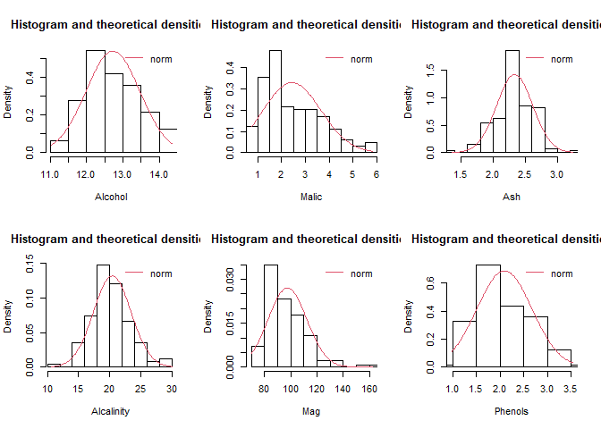

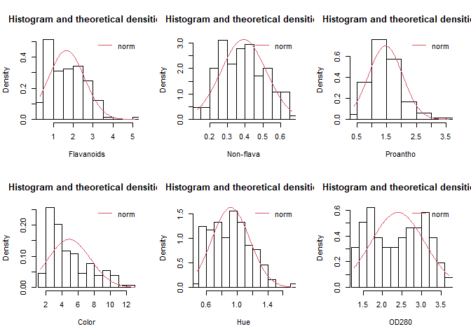

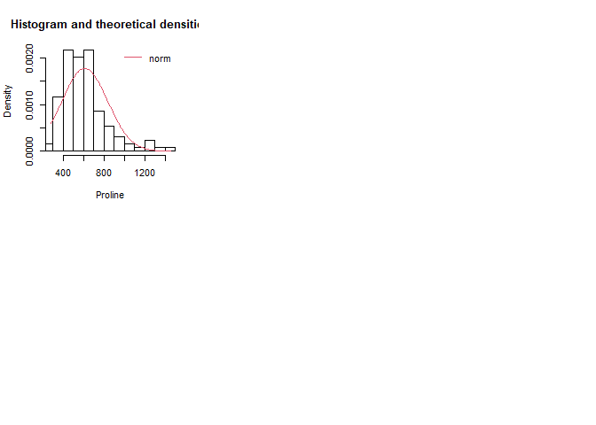

Aplicamos el test

```r
sapply(1:ncol(datos.num.reducidos), test_Grubbs, datos=datos.num)
```

```
                         [,1]      [,2]      [,3]       [,4]         [,5]
nombre.columna           "Alcohol" "Malic"   "Ash"      "Alcalinity" "Mag"
clave.mas.alejado.media  67        75        11         11           47
valor.mas.alejado.media  11.03     5.8       1.36       10.6         162
nombre.mas.alejado.media "67"      "75"      "11"       "11"         "47"
es.outlier               TRUE      FALSE     FALSE      FALSE        TRUE
p.value                  0         0.6588083 0.05140175 0.1278085    0.0007741042
es.distrib.norm          FALSE     FALSE     TRUE       FALSE        FALSE
                         [,6]      [,7]         [,8]        [,9]       [,10]
nombre.columna           "Phenols" "Flavanoids" "Non-flava" "Proantho" "Color"
clave.mas.alejado.media  50        73           57          62         110
valor.mas.alejado.media  3.52      5.08         0.66        3.58       13
nombre.mas.alejado.media "50"      "73"         "57"        "62"       "110"
es.outlier               FALSE     TRUE         TRUE        TRUE       FALSE
p.value                  0.3121087 0.01407371   0           0.01991868 0.1929232
es.distrib.norm          FALSE     FALSE        FALSE       FALSE      FALSE
                         [,11]     [,12]
nombre.columna           "Hue"     "OD280"
clave.mas.alejado.media  67        73
valor.mas.alejado.media  1.71      3.69
nombre.mas.alejado.media "67"      "73"
es.outlier               FALSE     TRUE
p.value                  0.1416747 0
es.distrib.norm          FALSE     FALSE
```

Lo primero que vemos es que tras quitar el valor más alejado de la media en cada columna solo una (Ash) no es rechazada por el test de Shapiro. Por tanto es la única que no contradice la hipótesis de normalidad, pues del resto se afirma con garantía estadística que no lo son.

Del único outlier que debemos mirar con el test de Grubs, vemos que es la instancia 11, que conocíamos que contenía valores extremadamente bajos de los componentes. El p-value supera por poco nuestro nivel de significación, por lo que el test no lo rechaza con garantía estadística.

# 4 Outliers Multivariantes

## 4.1 Métodos estadísticos basados en la distancia de Mahalanobis

### 4.1.1 Hipótesis de Normalidad

Para que un par de variables siga una distribución normal conjunta ambas deben estar normalmente distribuídas de forma individual. Como el test de normalidad nos deja solo una (Ash), reducidos el nivel de significación a 0.025 para obtener otra variable más (esto no deberíamos aplicarlo en un problema real)

```r
test <- sapply(1:ncol(datos.num), test_Grubbs, datos=datos.num)
son.col.normales <- apply(test, 2, function(x) {
  x$es.distrib.norm
})
# Alpha = 0.05
son.col.normales
```

```
 [1] FALSE FALSE  TRUE FALSE FALSE FALSE FALSE FALSE FALSE FALSE FALSE FALSE FALSE
```

```r
test <- sapply(1:ncol(datos.num), test_Grubbs, alpha=0.025, datos=datos.num)
son.col.normales <- apply(test, 2, function(x) {
  x$es.distrib.norm
})
datos.num.distrib.norm = datos.num[,son.col.normales]

# Alpha = 0.025
son.col.normales
```

```
 [1] FALSE FALSE  TRUE FALSE FALSE FALSE FALSE  TRUE FALSE FALSE FALSE FALSE FALSE
```

```r
head(datos.num.distrib.norm)
```

|  | Ash | Non-flava |
| --- | --- | --- |
| 1 | 2.68 | 0.31 |
| 2 | 2.72 | 0.33 |
| 3 | 2.36 | 0.42 |
| 4 | 2.61 | 0.31 |
| 5 | 2.30 | 0.26 |
| 6 | 2.40 | 0.32 |

Aplicamos un test de Normalidad multivariante para comprobar la condición:

| MVN |
| --- |
| YES |

| p value |
| --- |
| 0.086 |

El test multivariante no rechaza la hipótesis nula, por lo que no nos asegura que la distribución conjunta de Ash y Non-flava no es normal. Nuestro test indidual nos había dicho que no lo era, aunque recordamos que si no quitámos el valor más alejado de la media no lo negaba (y con este valor MVN hizo el test).

No deberíamos por tanto aplicar este método con distancia de Mahalanobis si queremos garantía estadística, pues la condición de que las variables se distribuyan de forma normal es necesaria.

### 4.1.2 Tests de hipótesis para detectar outliers

Mostramos los outliers con y sin método robusto

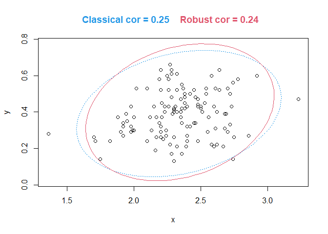

```
$cor.cla
[1] 0.2517533

$cor.rob
[1] 0.24272
```

Podemos ver que hay tres puntos fuera de las elipses, dos considerablemente más alejados que el tercero. También apreciamos que el uso o no de un método robusto no nos cambia significativamente la forma de los resultados.

Aplicamos un test individual y un test múltiple, ajustando el parámetro alpha de forma que corrijamos el FWER:

```r
set.seed(2)

cerioli.individual <- cerioli2010.fsrmcd.test(datos.num.distrib.norm, signif.alpha = 0.05)
claves.test.individual <- which(cerioli.individual$outliers)
nombres.test.individual <- nombres_filas(datos.num.distrib.norm, claves.test.individual)

n <- nrow(datos.num)
alpha <- 0.05
cerioli.interseccion <- cerioli2010.fsrmcd.test(datos.num.distrib.norm, signif.alpha = 1 - (1 - alpha)^(1/n))
claves.test.interseccion <- which(cerioli.interseccion$outliers)
nombres.test.interseccion <- nombres_filas(datos.num.distrib.norm, claves.test.individual)

claves.test.individual
# nombres.test.individual
claves.test.interseccion
# nombres.test.interseccion
```

```
[1] 11 21 48 73
integer(0)
```

El test de intersección no nos devuelve ningún outlier, pero el indivual nos saca cuatro puntos. Todos estos fueron detectados como outliers por el método IQR en alguna columan, siendo 11 y 73 en más de una.

Si se cumpliera el requisito de distribución normal multivariante, tendríamos garantía estadística en la instancia con mayor distancia Mahalanobis.

Mostramos las distancias de forma ordenada:

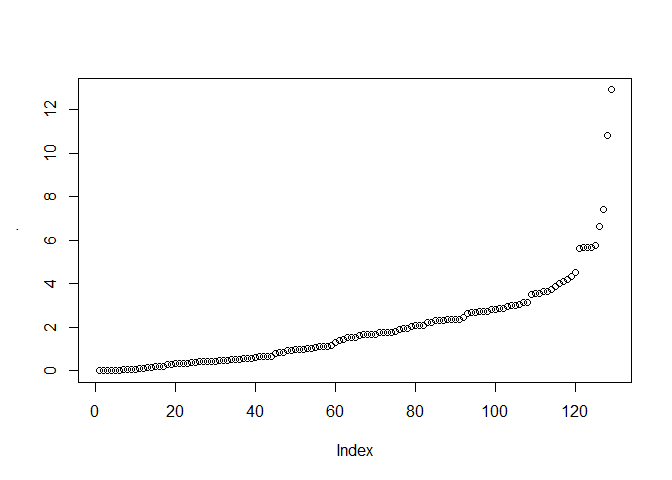

```r
cerioli.individual$mahdist.rw %>% sort() %>% plot()
```

Apreciando los cuatro puntos vistos anteriormente y un segundo conjunto de puntos un poco por debajo. Este conjunto probablemente esté algo alejado de la nube de puntos, pero no sean outliers.

Si mostramos las claves y las distancias, obtenemos:

```r
clave.mayor.dist.Mah <- order(cerioli.individual$mahdist.rw, decreasing = TRUE)[1]
nombre.mayor.dist.Mah <- nombres_filas(datos.num, clave.mayor.dist.Mah)

cerioli.individual$mahdist
clave.mayor.dist.Mah
# nombre.mayor.dist.Mah
```

```
           1            2            3            4            5            6
 3.758126468  4.145692423  0.022881637  2.618487841  0.675169904  0.448245304
           7            8            9           10           11           12
 1.097042604  2.114789069  0.566013904  2.616878861 19.157207664  3.048621260
          13           14           15           16           17           18
 4.553582205  3.368802348  1.497126216  0.611383364  1.251124352  7.591744173
          19           20           21           22           23           24
 3.167711814  1.018134342  6.308808654  0.333865173  5.786938244  0.545418969
          25           26           27           28           29           30
 4.465150067  2.831425942  3.512181973  7.214390873  0.475388671  3.080300573
          31           32           33           34           35           36
 0.067853783  2.095811278  0.690852446  0.601316025  2.260530038  3.894954045
          37           38           39           40           41           42
 0.345628580  0.119868051  1.689284756  0.332914322  0.107440795  0.814040132
          43           44           45           46           47           48
 0.387952380  2.184627278  0.738787990  1.917832584  0.391614656  9.560088088
          49           50           51           52           53           54
 2.338039842  1.271908812  0.773649628  7.591744173  3.551936314  0.633230450
          55           56           57           58           59           60
 4.572235111  2.430644480  3.895750353  0.998565758  0.589265387  3.654279438
          61           62           63           64           65           66
 4.512131313  4.837865010  0.784249435  5.830799528  0.462341642  0.442150490
          67           68           69           70           71           72
 1.732053477  2.225589549  0.414843810  3.462572339  2.457921442  0.553971395
          73           74           75           76           77           78
16.070169702  3.029120108  0.822590817  1.836991425  0.583804462  0.059389050
          79           80           81           82           83           84
 3.402123081  0.052520112  0.031081805  1.406673840  1.408279287  0.980827175
          85           86           87           88           89           90
 2.380094155  2.690943698  4.002416481  0.889587236  2.358811687  2.959961558
          91           92           93           94           95           96
 1.335585089  2.236489893  0.032165901  2.506274111  0.243840058  0.500769929
          97           98           99          100          101          102
 1.122001729  0.315323437  0.364514893  0.107534959  0.165739365  4.574357231
         103          104          105          106          107          108
 2.135989288  6.233143656  2.603812238  3.189386467  2.260530038  0.264915355
         109          110          111          112          113          114
 2.358811687  2.236489893  1.568021366  0.414795198  0.744062583  1.685832700
         115          116          117          118          119          120
 0.001253032  0.075484496  1.191177056  1.271279132  0.052520112  2.773421910
         121          122          123          124          125          126
 8.718529154  0.018368322  0.589265387  0.325819295  0.558627569  0.330904594
         127          128          129
 0.307956043  0.734306740  2.798182125
[1] 11
```

Si cumpliéramos el requisito de normalidad, concluiríamos con garantía estadística que el registro 11 rechaza la hipótesis y es un outlier.

## 4.2 Visualización de datos con un Biplot

Mostramos visualmente información resumida del conjunto de datos en dos variables, junto a los outliers detectados mediante alguna columna con IQR:

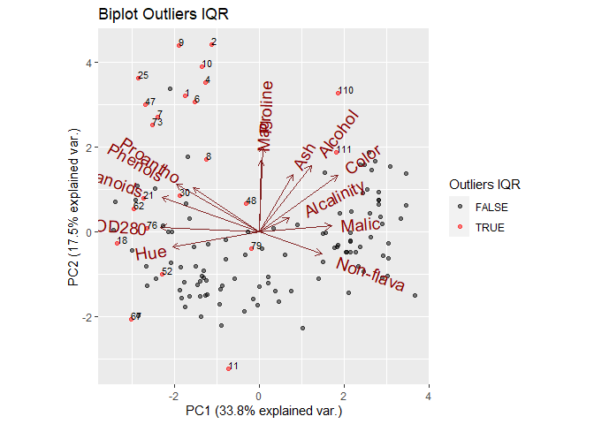

Lo primero que debemos notar es que el biplot no explica un alto porcentaje de las varianzas, probablemente por la cantidad de variables, que haga difícil explicar la variabilidad de los datos en solo dos componentes. Esto hace que nuestra confianza en los valores mostrados en el biplot no sea muy alta, pues existe una alta variabilidad no mostrada en el gráfico. Además, vemos que una gran cantidad de outliers se ubican con valores altos en alguna columna, alejados del centro. Solo la instancia 11 se aprecia con valores muy inferiores en un conjunto de variables (Ash, Alcohol, Mag…) pero con valores normales en el resto.

También apreciamos que las variables están agrupadas en tres grupos, con correlaciones positivas y negativas entre ellas.

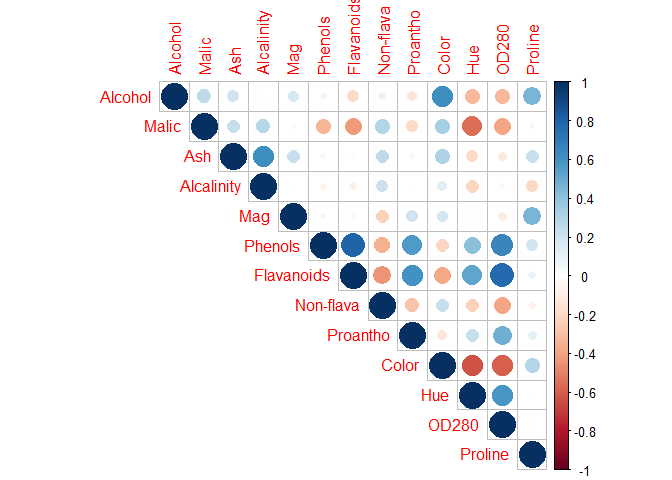

```r
corrplot::corrplot(cor(datos.num), type="upper")
```

Podemos reducir las variables seleccionadas de cara a obtener una varianza explicada mayor en el biplot:

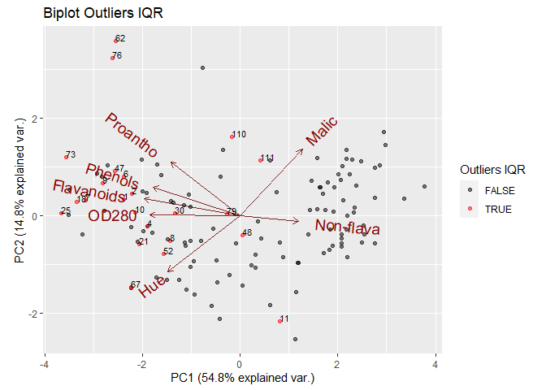

```r
biplot.outliers.IQR = biplot_2_colores(datos.num[,-c(1,3,4,5,10,13)],
                                       claves.outliers.IQR.en.alguna.columna,
                                       titulo.grupo.a.mostrar = "Outliers IQR",
                                       titulo ="Biplot Outliers IQR")
biplot.outliers.IQR
```

No tenemos la información expresada por las variables que hemos quitado, pero en base a estas obtenemos una variabilidad explicada del 14.8+54.8=69.6%, y podemos intentar interpretar de nuevo los resultados.

Primero vemos que la mayoría de outliers se ubican en la parte izquierda del biplot. Al tener variables correladas, se aprecia que muchos tienen alta cantidad de Phenols, Flavanoilds… mientras contienen bajo grado de Non-Flavanoids. Por otro lado tenemos un par de instancias en la esquina superior izquierda con nuevamente valores altos en varias columnas.

Volvemos a fijarnos en la instancia 11, que en las variables seleccionadas contiene valores mayormente normales. Era en las columnas Alcalinity y Ash donde contenía valores anormalmente bajos. Aún así vemos que la combinación de las variables seleccionadas es algo inusual, pero no demasiado, pues existe algunos puntos cercanos a su área.

Concluímos diciendo que se aprecia enormemente en este dataset que la información proporcionada por un biplot debe ser una ayuda al científico, y no el único método en el que basarse para la detección de outliers.

## 4.3 Métodos basados en distancias: LOF

La selección de un buen número de vecinos es vital para los métodos basados en vecinos más cercanos. Un valor demasiado grande puede hacernos detectar como outliers nubes con bajo número de puntos, mientras que uno demasiado alto puede ocultar outliers como tales. El método LOF basado en densidad paliará en parte estos problemas, pero sigue siendo necesaria una selección cuidadosa de este valor.

En base a las gráficas vistas a lo largo de la práctica, concretamente las de la sección Gráficos, vemos a la mayoría de puntos generalmente agrupados en la misma nube, no apreciando multiples agrupaciones diferentes (debemos tener cuidado con esto puesto que así no tenemos en cuenta los outliers con valores anómalos en más de dos columnas). En base a este razonamiento, elegimos un número de vecinos medianamente alto, de 7.

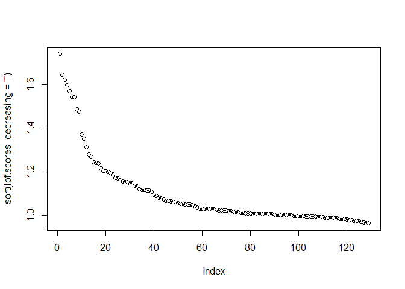

```r
plot(sort(lof.scores, decreasing = T))
```

Vemos un valor con un alto grado de anomalía y dos conjuntos que lo siguen, el primero formado por seis instancias y el segundo por dos.

Analizamos este punto y el primer conjunto:

```r
claves.outliers.lof <- order(lof.scores, decreasing = T) %>% head(num.vecinos.lof)
# nombres.outliers.lof <- nombres_filas(datos.num.norm, claves.outliers.lof)

claves.outliers.lof
# nombres.outliers.lof
```

```
[1]  73  21 110  25  62  47  11
```

Mostramos también los valores normalizados de dichos registros:

|  | Alcohol | Malic | Ash | Alcalinity | Mag | Phenols | Flavanoids | Non-flava | Proantho | Color | Hue | OD280 | Proline |
| --- | --- | --- | --- | --- | --- | --- | --- | --- | --- | --- | --- | --- | --- |
| 73 | -1.5691817 | -0.3258907 | 3.1692322 | 2.6406101 | 1.45484164 | 1.8729729 | 3.7651414 | 0.6154213 | 0.7022772 | 0.4229639 | 0.04562371 | 1.8889961 | -0.6523463 |
| 21 | -0.6946909 | -1.0342434 | -2.0790097 | -1.1967410 | 3.61512449 | -0.4094758 | -0.4217655 | -1.9682556 | 1.8017583 | -0.7904743 | 1.46234337 | 0.9875527 | 0.4696893 |
| 110 | 2.1709481 | -0.6306471 | 1.2897942 | 1.4926846 | 0.03715603 | 1.2208447 | -0.3887110 | 1.0851807 | 2.1507999 | 3.1194935 | -1.41157366 | -0.6263217 | 0.2124638 |
| 25 | 0.3546981 | -0.6388838 | 0.9351833 | 3.1325782 | 2.80501842 | 2.0789081 | 1.3521608 | -1.4202029 | 0.8593459 | -0.5978651 | 1.58377648 | 1.6127473 | 1.6538139 |
| 62 | -1.7037187 | 1.0661046 | -1.8307821 | -0.3111984 | 0.64473558 | 1.8729729 | 1.0105974 | -1.1853232 | 3.6865830 | -0.7712134 | -0.68297497 | 0.6095281 | -0.2221587 |
| 47 | -0.3448946 | -0.7624336 | -0.4832605 | -0.4751878 | 4.35772172 | 0.7060066 | 0.6690339 | -0.5589773 | 3.1630206 | -0.8867790 | 0.97661091 | 0.3478187 | 1.4409375 |
| 11 | -0.4794316 | -1.2401598 | -3.4619924 | -3.2302091 | -0.63793236 | -0.1863794 | -1.2040560 | -0.8721503 | -1.8282746 | -1.1371710 | 0.53135616 | -0.8298734 | -0.4084255 |

Lo que más nos llama la atención primeramente es que de este conjunto de instancias la 11, la cuál nos ha aparecido múltiples veces a lo largo de la memoria, es la que menor grado LOF de anomalía tiene.

La que más obtiene es la 73, que también había sido detectada por los métodos anteriores. Visualizando sus datos normalizados, vemos que solo tiene valores alejados en dos columnas (tres si consideramos Alcalinity). El resto de instancias mayoritariamente solo tienen un valor extremo en una columna, lo que ya les otorga un alto score de LOF.

Analizamos el registro con mayor score de LOF (73) en diagramas de dispersión (puesto que la figura es excesivamente grande con todas las variables, seleccionamos aquellas en las que contine valores extremos)

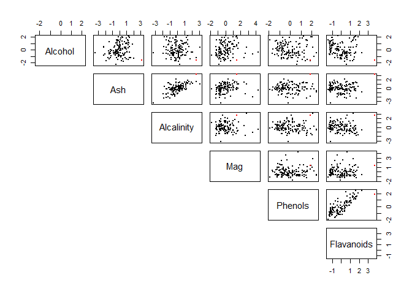

Las correlaciones las vimos anteriormente, pero se hace notoria la relación Phenols-Flavanoids, con la instancia 73 más baja de lo que sería esperado si siguieramos una línea de regresión sobre esos datos. Con Ash-Alcalinity ocurre algo similar, pero el punto se ubica alejado del resto, sin contradecir la tendencia.

También vemos que los valores de esta instancia se ven extremadamente altos en Ash y Flavanoids, situándolo en las esquinas cuando se muestran estas variables. En el resto, en la mayoría de casos el punto está algo alejado del centro de la distribución pero no de manera extrema.

Volvemos a mostrar los biplots pero en este caso fijándonos en esta instancia:

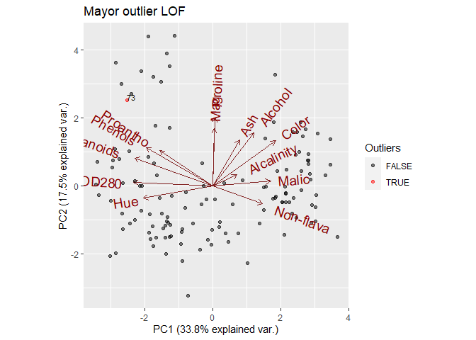

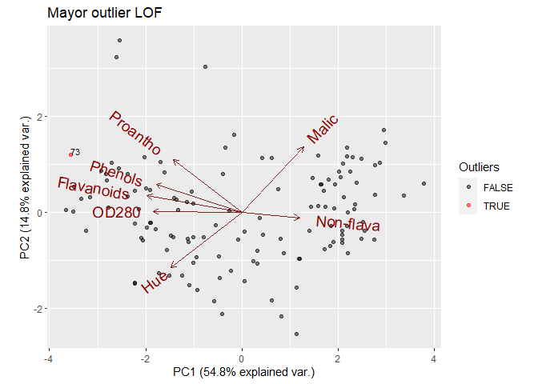

Como habíamos mencionado, contiene inusualmente valores altos en varias variables, pero se sigue ubicando en una zona relativamente densidad.

Otros puntos que se sitúan por esa zona y con scores altos en LOF es el 25 y el 47. Los mostramos:

|  | Alcohol | Malic | Ash | Alcalinity | Mag | Phenols | Flavanoids | Non-flava | Proantho | Color | Hue | OD280 | Proline |
| --- | --- | --- | --- | --- | --- | --- | --- | --- | --- | --- | --- | --- | --- |
| 73 | -1.5691817 | -0.3258907 | 3.1692322 | 2.6406101 | 1.454842 | 1.8729729 | 3.7651414 | 0.6154213 | 0.7022772 | 0.4229639 | 0.04562371 | 1.8889961 | -0.6523463 |
| 25 | 0.3546981 | -0.6388838 | 0.9351833 | 3.1325782 | 2.805018 | 2.0789081 | 1.3521608 | -1.4202029 | 0.8593459 | -0.5978651 | 1.58377648 | 1.6127473 | 1.6538139 |
| 47 | -0.3448946 | -0.7624336 | -0.4832605 | -0.4751878 | 4.357722 | 0.7060066 | 0.6690339 | -0.5589773 | 3.1630206 | -0.8867790 | 0.97661091 | 0.3478187 | 1.4409375 |

En los dos primeros notamos un alto grado de Alcalinity, y en los dos últimos de Magnesio, pero no se aprecia una característica extrema común que los relacione a todos.

## 4.4 Métodos basados en Clustering

### 4.4.1 Clustering usando K-means

Para esta parte, al no tener clústers predefinidos, seleccionamos un número de 3 y la cantidad de outliers a 5.

Construímos el modelo K-means:

```r
modelo.kmeans <- kmeans(datos.num.norm, num.clusters)
asignaciones.clustering.kmeans <- modelo.kmeans$cluster
centroides.normalizados <- modelo.kmeans$centers

head(asignaciones.clustering.kmeans)
```

```
1 2 3 4 5 6
2 2 2 2 2 2
```

```r
centroides.normalizados %>% as.data.frame()
```

|  | Alcohol | Malic | Ash | Alcalinity | Mag | Phenols | Flavanoids | Non-flava | Proantho | Color | Hue | OD280 | Proline |
| --- | --- | --- | --- | --- | --- | --- | --- | --- | --- | --- | --- | --- | --- |
| 1 | 0.5721538 | 0.7403363 | 0.3489897 | 0.32467871 | 0.1060426 | -0.70436948 | -0.9528866 | 0.46522608 | -0.53147813 | 0.94041459 | -0.9423627 | -1.0185890 | 0.06855503 |
| 2 | 0.3798506 | -0.6614450 | 0.1581228 | -0.45807585 | 0.8678083 | 1.33052755 | 1.3200644 | -0.81428135 | 1.10671016 | -0.08987912 | 0.7020665 | 0.8554338 | 1.23693107 |
| 3 | -0.6451246 | -0.3695306 | -0.3638126 | -0.09427214 | -0.4413277 | 0.06863107 | 0.2864906 | -0.07136152 | 0.01031745 | -0.77215956 | 0.5268113 | 0.5304541 | -0.55804581 |

Y mostramos los valores de los centroides desnormalizados:

|  | Alcohol | Malic | Ash | Alcalinity | Mag | Phenols | Flavanoids | Non-flava | Proantho | Color | Hue | OD280 | Proline |
| --- | --- | --- | --- | --- | --- | --- | --- | --- | --- | --- | --- | --- | --- |
| 1 | 13.15163 | 3.344490 | 2.434694 | 21.43878 | 99.02041 | 1.678163 | 0.7979592 | 0.4508163 | 1.163061 | 7.343265 | 0.6859184 | 1.690204 | 627.5510 |
| 2 | 13.00870 | 1.642609 | 2.380870 | 19.05217 | 110.30435 | 2.863913 | 2.8608696 | 0.2873913 | 2.101739 | 4.668696 | 1.0921739 | 2.979130 | 891.0000 |
| 3 | 12.24684 | 1.997018 | 2.233684 | 20.16140 | 90.91228 | 2.128596 | 1.9228070 | 0.3822807 | 1.473509 | 2.897544 | 1.0488772 | 2.755614 | 486.2632 |

Función para calcular los outliers:

```r
#######################################################################
# Calcula las distancias de los datos a los centroides
# y se queda con los primeros (tantos como indica num.outliers)
# Devuelve una lista con las claves de dichos registros y las
# correspondientes distancias a sus centroides
#######################################################################
top_clustering_outliers = function(datos.normalizados,
                                   asignaciones.clustering,
                                   datos.centroides.normalizados,
                                   num.outliers){
  distancias <- distancias_a_centroides(datos.normalizados,
                                        asignaciones.clustering,
                                        datos.centroides.normalizados)
  claves <- distancias %>% order(decreasing = T) %>% head(num.outliers)

  res <- list()
  res$distancias <- distancias %>% sort(decreasing = T) %>% head(num.outliers)
  res$claves <- claves
  res
}
```

Y obtenemos los outliers:

```
[1]  73  11  21 110  62
      73       11       21      110       62
6.061054 5.345231 4.893164 4.841143 4.807096
```

Instancias que también habíamos obtenido con otros métodos.

Mostramos en un biplot estos outliers y los clusters:

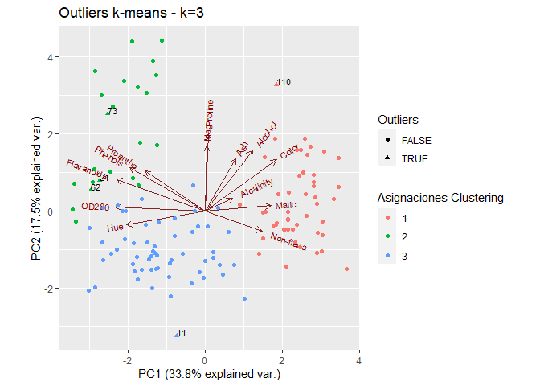

No mostramos el biplot con el número reducido de columnas pues la separación en clústers ha hecho uso de todas las variables.

Apreciamos que se detecta un solo outlier en los grupos 1 y 3, estando estos bastante alejados de la nube de puntos a la que pertenecen. Respecto a los del grupo 2, este es un clúster bastante disperso en este biplot (recordamos que la varianza explicada es baja), y los outliers están alejados de su centroide.

Sabemos que un outlier detectado como tal en una partición grande de clústers es más probable que lo sea. Probamos por tanto a repetir el proceso incrementando el número de clústers a 5.

Centroides normalizados:

|  | Alcohol | Malic | Ash | Alcalinity | Mag | Phenols | Flavanoids | Non-flava | Proantho | Color | Hue | OD280 | Proline |
| --- | --- | --- | --- | --- | --- | --- | --- | --- | --- | --- | --- | --- | --- |
| 1 | 1.2639442 | -0.5427894 | 0.52738069 | -0.6391772 | 1.25231513 | 1.3166617 | 1.3273699 | -0.6372705 | 0.84771116 | 0.1706458 | 0.7404910 | 0.8821420 | 2.37153231 |
| 2 | -0.8142794 | -0.4357129 | -0.02226627 | 0.5099631 | -0.69293956 | -0.1870150 | 0.1899473 | 0.3370453 | 0.01582863 | -0.8414088 | 0.6153099 | 0.5971427 | -0.55559926 |
| 3 | -0.3045335 | -0.7377237 | -1.06941152 | -1.1137817 | 0.56134231 | -0.4114948 | -0.2642704 | -0.3885744 | -0.46495909 | -0.6044365 | 0.5923108 | -0.1944157 | -0.09615472 |
| 4 | -0.6344183 | -0.2543965 | -0.18822419 | -0.1550805 | -0.37599807 | 1.1906408 | 1.1868882 | -0.7625397 | 0.89704238 | -0.6177424 | 0.3985893 | 0.9962764 | -0.60409432 |
| 5 | 0.5803279 | 0.7745612 | 0.35746295 | 0.3481755 | 0.07372332 | -0.6983572 | -0.9632630 | 0.5045059 | -0.52336796 | 0.9664430 | -0.9486099 | -1.0064666 | 0.06832876 |

Centroides desnormalizados:

|  | Alcohol | Malic | Ash | Alcalinity | Mag | Phenols | Flavanoids | Non-flava | Proantho | Color | Hue | OD280 | Proline |
| --- | --- | --- | --- | --- | --- | --- | --- | --- | --- | --- | --- | --- | --- |
| 1 | 13.66583 | 1.786667 | 2.485000 | 18.50000 | 116.00000 | 2.855833 | 2.8675000 | 0.3100000 | 1.953333 | 5.345000 | 1.101667 | 2.997500 | 1146.8333 |
| 2 | 12.12111 | 1.916667 | 2.330000 | 22.00370 | 87.18519 | 1.979630 | 1.8351852 | 0.4344444 | 1.476667 | 2.717778 | 1.070741 | 2.801481 | 486.8148 |
| 3 | 12.50000 | 1.550000 | 2.034706 | 17.05294 | 105.76471 | 1.848824 | 1.4229412 | 0.3417647 | 1.201176 | 3.332941 | 1.065059 | 2.257059 | 590.4118 |
| 4 | 12.25480 | 2.136800 | 2.283200 | 19.97600 | 91.88000 | 2.782400 | 2.7400000 | 0.2940000 | 1.981600 | 3.298400 | 1.017200 | 3.076000 | 475.8800 |
| 5 | 13.15771 | 3.386042 | 2.437083 | 21.51042 | 98.54167 | 1.681667 | 0.7885417 | 0.4558333 | 1.167708 | 7.410833 | 0.684375 | 1.698542 | 627.5000 |

Obtenemos los outliers:

```
[1]  73 110  47  25  21
      73      110       47       25       21
5.863094 4.816867 4.671932 4.602683 4.556194
```

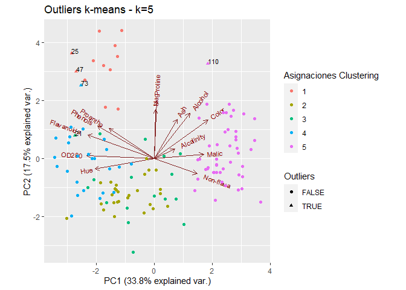

Mostramos los outliers obtenidos con un k=5 en un diagrama de cajas:

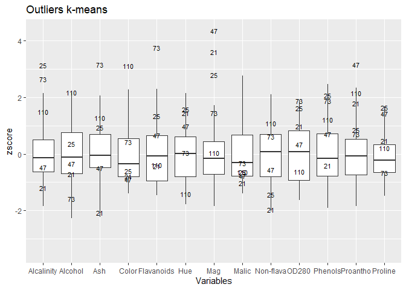

### 4.4.2 Clustering usando medoides

Seguiremos usando 5 clústers para el método PAM.

Obtenemos los medoides:

```
Claves medoides: [1] "10"  "49"  "43"  "54"  "100"
```

|  | Alcohol | Malic | Ash | Alcalinity | Mag | Phenols | Flavanoids | Non-flava | Proantho | Color | Hue | OD280 | Proline |
| --- | --- | --- | --- | --- | --- | --- | --- | --- | --- | --- | --- | --- | --- |
| 10 | 13.77 | 1.90 | 2.68 | 17.1 | 115 | 3.00 | 2.79 | 0.39 | 1.68 | 6.30 | 1.13 | 2.93 | 1375 |
| 49 | 12.29 | 1.41 | 1.98 | 16.0 | 85 | 2.55 | 2.50 | 0.29 | 1.77 | 2.90 | 1.23 | 2.74 | 428 |
| 43 | 12.00 | 1.51 | 2.42 | 22.0 | 86 | 1.45 | 1.25 | 0.50 | 1.63 | 3.60 | 1.05 | 2.65 | 450 |
| 54 | 12.34 | 2.45 | 2.46 | 21.0 | 98 | 2.56 | 2.11 | 0.34 | 1.31 | 2.80 | 0.80 | 3.38 | 438 |
| 100 | 13.32 | 3.24 | 2.38 | 21.5 | 92 | 1.93 | 0.76 | 0.45 | 1.25 | 8.42 | 0.55 | 1.62 | 650 |

Y sus valores normalizados:

|  | Alcohol | Malic | Ash | Alcalinity | Mag | Phenols | Flavanoids | Non-flava | Proantho | Color | Hue | OD280 | Proline |
| --- | --- | --- | --- | --- | --- | --- | --- | --- | --- | --- | --- | --- | --- |
| 10 | 1.4040870 | -0.449440618 | 1.2188720 | -1.0983474 | 1.18480629 | 1.5640700 | 1.2419791 | -0.01092464 | 0.3706876 | 0.5385295 | 0.8551778 | 0.7840010 | 3.3834340 |
| 49 | -0.5870613 | -0.853036888 | -1.2634046 | -1.4591240 | -0.84045888 | 0.7918129 | 0.9224520 | -0.79385703 | 0.5277563 | -0.7712134 | 1.2599548 | 0.5077522 | -0.8164385 |
| 43 | -0.9772187 | -0.770670302 | 0.2968836 | 0.5087484 | -0.77295004 | -1.0959266 | -0.4548201 | 0.85030099 | 0.2834272 | -0.5015605 | 0.5313562 | 0.3768975 | -0.7188701 |
| 54 | -0.5197927 | 0.003575604 | 0.4387280 | 0.1807697 | 0.03715603 | 0.8089742 | 0.4927431 | -0.40239083 | -0.2750394 | -0.8097353 | -0.4805865 | 1.4382744 | -0.7720892 |
| 100 | 0.7986703 | 0.654271631 | 0.1550392 | 0.3447590 | -0.36789701 | -0.2721857 | -0.9947107 | 0.45883480 | -0.3797519 | 1.3551927 | -1.4925291 | -1.1206616 | 0.1681145 |

Calculamos los cinco posibles outliers:

```r
top.outliers.pam = top_clustering_outliers(datos.num.norm ,
                                              asignaciones.clustering.pam,
                                              medoides.normalizados,
                                              num.outliers)
claves.outliers.pam = top.outliers.pam$claves
# nombres.outliers.pam = nombres_filas(datos.num, claves.outliers.pam)

claves.outliers.pam
# nombres.outliers.pam
```

```
[1] 73 47 25 21 62
```

Y creamos un biplot:

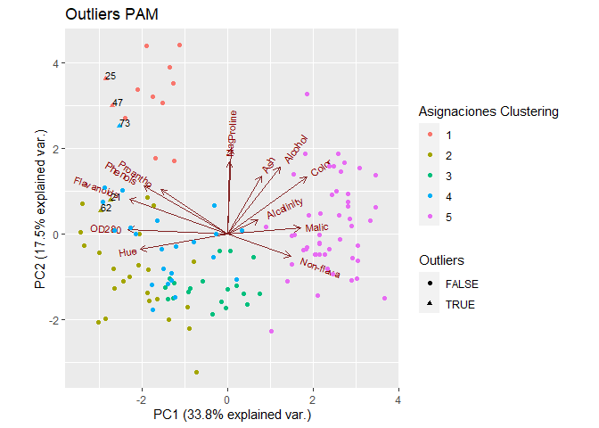

```r
biplot_outliers_clustering(datos.num,
                           titulo = "Outliers PAM",
                           asignaciones.clustering = asignaciones.clustering.pam,
                           claves.outliers = claves.outliers.pam)
```

En este caso los outlier se ubican en la parte izquierda, no muy alejados de sus nubes de puntos pero si con valores extremos en al menos alguna de las componentes principales del biplot. De estos outliers, habíamos obtenido con k-means las instancias 73, 25 y 21, y con un valor de k=3 también la 62.

Mostramos un diagrama de cajas con estos puntos:

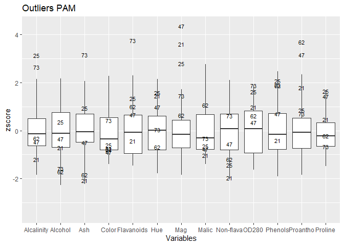

### 4.4.3 Análisis de los outliers multivariantes puros

Calculamos aquellos outliers que no lo son para una variable separadamente

```r
claves.outliers.lof.no.IQR <- setdiff(claves.outliers.lof, claves.outliers.IQR.en.alguna.columna)
nombres.outliers.lof.no.IQR <- nombres_filas(datos.num, claves.outliers.lof.no.IQR)

# nombres.outliers.lof.no.IQR
claves.outliers.IQR.en.alguna.columna
```

```
 [1]  11  18  52  73  25  79  21  30  47  48  62  76 110 111  67   1   2   4   6   7   8
[22]   9  10
```

```r
claves.outliers.lof
```

```
[1]  73  21 110  25  62  47  11
```

```r
claves.outliers.lof.no.IQR
```

```
integer(0)
```

Vemos que no obtenemos ningún outlier puramente multivariable, todos son extremos en alguna de ellas.

En el método LOF vimos que había 3 conjuntos de puntos con scores altos, con un total de 9 instancias. Volvemos a calcular los outliers LOF aumentando el umbral a 9 puntos, y buscamos los multivariables puros:

```r
claves.outliers.lof.no.IQR <- setdiff(claves.lof.ordenados %>% head(9), claves.outliers.IQR.en.alguna.columna)
nombres.outliers.lof.no.IQR <- nombres_filas(datos.num, claves.outliers.lof.no.IQR)

# nombres.outliers.lof.no.IQR
claves.outliers.IQR.en.alguna.columna
```

```
 [1]  11  18  52  73  25  79  21  30  47  48  62  76 110 111  67   1   2   4   6   7   8
[22]   9  10
```

```r
claves.lof.ordenados %>% head(11)
```

```
 [1]  73  21 110  25  62  47  11  30  23  48 111
```

```r
claves.outliers.lof.no.IQR
```

```
[1] 23
```

Mostramos el biplot de los outliers puros:

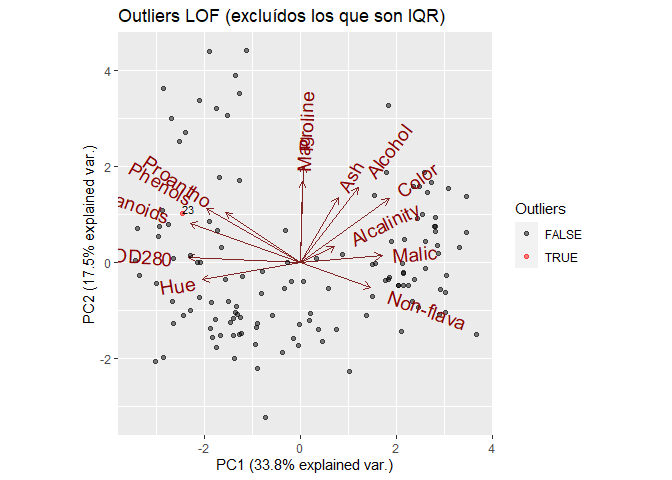

Ahora sí obtenemos un registro, el número 23.

Mostramos sus valores normalizados:

|  | . |
| --- | --- |
| Alcohol | 1.5251703 |
| Malic | -0.7706703 |
| Ash | 1.1834109 |
| Alcalinity | 1.4926846 |
| Mag | -0.7729500 |
| Phenols | 1.4782637 |
| Flavanoids | 1.3191063 |
| Non-flava | -1.4202029 |
| Proantho | 0.7022772 |
| Color | -0.5863085 |

[output cut: 3 more lines]

Y vemos como no contiene ninguna cantidad extrema de ningún componente:

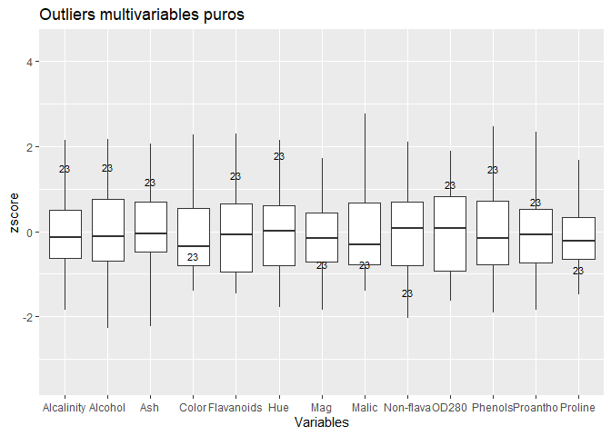

A partir del diagrama de cajas apreciamos que aunque no tienen un valor extremo en ninguna de las variables, en la mayoría contienen una cantidad un tanto alejada del centro de la distribución. Este hecho sea lo que probablemente haga aumentar el score de LOF y presente un alto grado de anomalía.

# 5 Análisis de resultados

**Conjunto de datos**

Se ha trabajado con el dataset *wine*, que codifica la cantidad de diversos componentes en varios vinos italianos. Todas las variables son numéricas y con suficiente variabilidad, por lo que no se ha eliminado ninguna.

Hemos aplicado la normalización por z-score en aquellos métodos que así lo han requerido.

**Outliers en una variable**

- **Método IQR**

No hemos encontrado outliers extremos pero sí hay cuatro outliers no extremos.

La instancia 11 es un vino con bajas cantidades de la mayoría de componentes, siendo extremo IQR en múltiples de ellas.

Existen al menos alguna instancia con valores altos en prácticamente todas las variables, aunque estos se acumulan más en las columnas de Magnesio y Proline.

Aunque sean vinos del mismo país, las diferentes formas de cultivo en las regiones y los diferentes terrenos hagan que los vinos acumulen una mayor cantidad de ciertos componentes. También es posible que el tiempo de fermetación afecte a las cantidades, con mayor grado en Ash y Alcohol.

No se aprecia ninguna característica común que agrupe a varios vinos.

- **Test de Hipótesis**

**Outliers multivariantes**

- **Visualización con biplot**

- **Métodos estadísticos usando la distancia de Mahalanobis**

El test de intersección no devuelve ningún outlier, mientras que el test individual devuelve cuatro outliers, todos detectados previamente con el método IQR. La instancia con mayor distancia de Mahalanobis era la 11, que como hemos comentado contiene valores extremadamente bajos en múltiples componentes. Al no cumplir los requisitos de normalidad, este método no puede afirmar con garantía estadística que sea un outlier.

- **LOF**

El gráfico de scores mostró tres grupos diferentes: un valor muy alto, un conjunto de seis puntos y uno de dos. De los siete puntos con mayor grado de anomalía, todos tenían un valor extremo en al menos una columna, siendo la causa de este score alto.

En base al método LOF se detecta un outlier multivariante puro en el tercer grupo de puntos. Esta instancia, la 23, contienen valores altos ligeramente alejados de las media en la mayoría de las columnas, ubicándose en torno al centro de la distribución solo en la variable Color.

- **Métodos basados en clustering**

Haciendo uso de medoides solo se han detectado instancias ya descubiertas.